# Loan Marketing Recommendation Model

A bank X is on a massive digital transformation for all its departments. Bank has a growing customer base whee majority of them are liability customers (depositors) vs borrowers (asset customers). The bank is interested in expanding the borrowers base rapidly to bring in more business via loan interests. A campaign that the bank ran in last quarter showed an average single digit conversion rate. Digital transformation being the core strength of the business strategy, marketing department wants to devise effective campaigns with better target marketing to increase the conversion ratio to double digit with same budget as per last campaign.

Dataset Attributes:

1. ID: Customer ID
2. Age Customer’s approximate age.
3. CustomerSince: Customer of the bank since. [unit is masked]
4. HighestSpend: Customer’s highest spend so far in one transaction. [unit is masked]
5. ZipCode: Customer’s zip code.
6. HiddenScore: A score associated to the customer which is masked by the bank as an IP.
7. MonthlyAverageSpend: Customer’s monthly average spend so far. [unit is masked]
8. Level: A level associated to the customer which is masked by the bank as an IP.
9. Mortgage: Customer’s mortgage. [unit is masked]
10. Security: Customer’s security asset with the bank. [unit is masked]
11. FixedDepositAccount: Customer’s fixed deposit account with the bank. [unit is masked]
12. InternetBanking: if the customer uses internet banking.
13. CreditCard: if the customer uses bank’s credit card.
14. LoanOnCard: if the customer has a loan on credit card.

```python
import pandas as  pd
import seaborn as sns
import matplotlib.pyplot as plt

import numpy as np
from sklearn.model_selection import train_test_split

from sklearn.neighbors import KNeighborsClassifier
from sklearn.metrics import accuracy_score

from sklearn.preprocessing import MinMaxScaler

from sklearn.metrics import confusion_matrix,classification_report
from sklearn.metrics import plot_confusion_matrix

import warnings
warnings.filterwarnings('ignore')
```

```python
%matplotlib inline
sns.set(color_codes=True)

class color:
   PURPLE = '\033[95m'
   CYAN = '\033[96m'
   DARKCYAN = '\033[36m'
   BLUE = '\033[94m'
   GREEN = '\033[92m'
   YELLOW = '\033[93m'
   RED = '\033[91m'
   BOLD = '\033[1m'
   UNDERLINE = '\033[4m'
   END = '\033[0m'
```

## 1. Import Dataset

```python
# Import all dataset
d1 = pd.read_csv("Part2 - Data1.csv")
d2 = pd.read_csv("Part2 -Data2.csv")
```

```python
# check size of each datset
print(f"Dataset Sizes:")
print(f"D1: {d1.shape}")
print(f"D2: {d2.shape}")
```

```
Dataset Sizes:
D1: (5000, 8)
D2: (5000, 7)
```

```python
# merge the different datasets and print shape of new the resultant
frames = [d1, d2]
dataset = pd.merge(d1,d2,on='ID')
dataset.head()
```

|  | ID | Age | CustomerSince | HighestSpend | ZipCode | HiddenScore | MonthlyAverageSpend | Level | Mortgage | Security | FixedDepositAccount | InternetBanking | CreditCard | LoanOnCard |
| --- | --- | --- | --- | --- | --- | --- | --- | --- | --- | --- | --- | --- | --- | --- |
| 0 | 1 | 25 | 1 | 49 | 91107 | 4 | 1.6 | 1 | 0 | 1 | 0 | 0 | 0 | NaN |
| 1 | 2 | 45 | 19 | 34 | 90089 | 3 | 1.5 | 1 | 0 | 1 | 0 | 0 | 0 | NaN |
| 2 | 3 | 39 | 15 | 11 | 94720 | 1 | 1.0 | 1 | 0 | 0 | 0 | 0 | 0 | NaN |
| 3 | 4 | 35 | 9 | 100 | 94112 | 1 | 2.7 | 2 | 0 | 0 | 0 | 0 | 0 | NaN |
| 4 | 5 | 35 | 8 | 45 | 91330 | 4 | 1.0 | 2 | 0 | 0 | 0 | 0 | 1 | NaN |

```python
dataset.tail()
```

|  | ID | Age | CustomerSince | HighestSpend | ZipCode | HiddenScore | MonthlyAverageSpend | Level | Mortgage | Security | FixedDepositAccount | InternetBanking | CreditCard | LoanOnCard |
| --- | --- | --- | --- | --- | --- | --- | --- | --- | --- | --- | --- | --- | --- | --- |
| 4995 | 4996 | 29 | 3 | 40 | 92697 | 1 | 1.9 | 3 | 0 | 0 | 0 | 1 | 0 | 0.0 |
| 4996 | 4997 | 30 | 4 | 15 | 92037 | 4 | 0.4 | 1 | 85 | 0 | 0 | 1 | 0 | 0.0 |
| 4997 | 4998 | 63 | 39 | 24 | 93023 | 2 | 0.3 | 3 | 0 | 0 | 0 | 0 | 0 | 0.0 |
| 4998 | 4999 | 65 | 40 | 49 | 90034 | 3 | 0.5 | 2 | 0 | 0 | 0 | 1 | 0 | 0.0 |
| 4999 | 5000 | 28 | 4 | 83 | 92612 | 3 | 0.8 | 1 | 0 | 0 | 0 | 1 | 1 | 0.0 |

```python
dataset.describe().transpose()
```

|  | count | mean | std | min | 25% | 50% | 75% | max |
| --- | --- | --- | --- | --- | --- | --- | --- | --- |
| ID | 5000.0 | 2500.500000 | 1443.520003 | 1.0 | 1250.75 | 2500.5 | 3750.25 | 5000.0 |
| Age | 5000.0 | 45.338400 | 11.463166 | 23.0 | 35.00 | 45.0 | 55.00 | 67.0 |
| CustomerSince | 5000.0 | 20.104600 | 11.467954 | -3.0 | 10.00 | 20.0 | 30.00 | 43.0 |
| HighestSpend | 5000.0 | 73.774200 | 46.033729 | 8.0 | 39.00 | 64.0 | 98.00 | 224.0 |
| ZipCode | 5000.0 | 93152.503000 | 2121.852197 | 9307.0 | 91911.00 | 93437.0 | 94608.00 | 96651.0 |
| HiddenScore | 5000.0 | 2.396400 | 1.147663 | 1.0 | 1.00 | 2.0 | 3.00 | 4.0 |
| MonthlyAverageSpend | 5000.0 | 1.937938 | 1.747659 | 0.0 | 0.70 | 1.5 | 2.50 | 10.0 |
| Level | 5000.0 | 1.881000 | 0.839869 | 1.0 | 1.00 | 2.0 | 3.00 | 3.0 |
| Mortgage | 5000.0 | 56.498800 | 101.713802 | 0.0 | 0.00 | 0.0 | 101.00 | 635.0 |
| Security | 5000.0 | 0.104400 | 0.305809 | 0.0 | 0.00 | 0.0 | 0.00 | 1.0 |
| FixedDepositAccount | 5000.0 | 0.060400 | 0.238250 | 0.0 | 0.00 | 0.0 | 0.00 | 1.0 |
| InternetBanking | 5000.0 | 0.596800 | 0.490589 | 0.0 | 0.00 | 1.0 | 1.00 | 1.0 |
| CreditCard | 5000.0 | 0.294000 | 0.455637 | 0.0 | 0.00 | 0.0 | 1.00 | 1.0 |
| LoanOnCard | 4980.0 | 0.096386 | 0.295149 | 0.0 | 0.00 | 0.0 | 0.00 | 1.0 |

```python
print(f"shape of dataset {dataset.shape}")
```

```
shape of dataset (5000, 14)
```

## 2. Dataset Cleaning

```python
dataset.info()
```

```
<class 'pandas.core.frame.DataFrame'>
Int64Index: 5000 entries, 0 to 4999
Data columns (total 14 columns):
 #   Column               Non-Null Count  Dtype
---  ------               --------------  -----
 0   ID                   5000 non-null   int64
 1   Age                  5000 non-null   int64
 2   CustomerSince        5000 non-null   int64
 3   HighestSpend         5000 non-null   int64
 4   ZipCode              5000 non-null   int64
 5   HiddenScore          5000 non-null   int64
 6   MonthlyAverageSpend  5000 non-null   float64
 7   Level                5000 non-null   int64
 8   Mortgage             5000 non-null   int64
 9   Security             5000 non-null   int64
 10  FixedDepositAccount  5000 non-null   int64
 11  InternetBanking      5000 non-null   int64
 12  CreditCard           5000 non-null   int64
 13  LoanOnCard           4980 non-null   float64
dtypes: float64(2), int64(12)
memory usage: 585.9 KB
```

DType is in an acceptable format

```python
#Check for null values
pd.DataFrame(dataset.isnull().sum(), columns=['No. of missing values'])
```

|  | No. of missing values |
| --- | --- |
| ID | 0 |
| Age | 0 |
| CustomerSince | 0 |
| HighestSpend | 0 |
| ZipCode | 0 |
| HiddenScore | 0 |
| MonthlyAverageSpend | 0 |
| Level | 0 |
| Mortgage | 0 |
| Security | 0 |
| FixedDepositAccount | 0 |
| InternetBanking | 0 |
| CreditCard | 0 |
| LoanOnCard | 20 |

There are 20 missing values on Loan, Since 20 is a small number compared to the size of dataset we can drop them. However, in this particular case, since its a true/false on boolean. we can fill the null values with mode.

```python
dataset['LoanOnCard'] = dataset['LoanOnCard'].fillna(dataset['LoanOnCard'].mode()[0])
```

Since LoanOnCard is a categorical value, it should be converted to int type for 1 and 0.

```python
dataset['LoanOnCard'] = dataset['LoanOnCard'].astype(int)
```

## 3. Data Analysis and Visualization

```python
dataset.describe().transpose()
```

|  | count | mean | std | min | 25% | 50% | 75% | max |
| --- | --- | --- | --- | --- | --- | --- | --- | --- |
| ID | 5000.0 | 2500.500000 | 1443.520003 | 1.0 | 1250.75 | 2500.5 | 3750.25 | 5000.0 |
| Age | 5000.0 | 45.338400 | 11.463166 | 23.0 | 35.00 | 45.0 | 55.00 | 67.0 |
| CustomerSince | 5000.0 | 20.104600 | 11.467954 | -3.0 | 10.00 | 20.0 | 30.00 | 43.0 |
| HighestSpend | 5000.0 | 73.774200 | 46.033729 | 8.0 | 39.00 | 64.0 | 98.00 | 224.0 |
| ZipCode | 5000.0 | 93152.503000 | 2121.852197 | 9307.0 | 91911.00 | 93437.0 | 94608.00 | 96651.0 |
| HiddenScore | 5000.0 | 2.396400 | 1.147663 | 1.0 | 1.00 | 2.0 | 3.00 | 4.0 |
| MonthlyAverageSpend | 5000.0 | 1.937938 | 1.747659 | 0.0 | 0.70 | 1.5 | 2.50 | 10.0 |
| Level | 5000.0 | 1.881000 | 0.839869 | 1.0 | 1.00 | 2.0 | 3.00 | 3.0 |
| Mortgage | 5000.0 | 56.498800 | 101.713802 | 0.0 | 0.00 | 0.0 | 101.00 | 635.0 |
| Security | 5000.0 | 0.104400 | 0.305809 | 0.0 | 0.00 | 0.0 | 0.00 | 1.0 |
| FixedDepositAccount | 5000.0 | 0.060400 | 0.238250 | 0.0 | 0.00 | 0.0 | 0.00 | 1.0 |
| InternetBanking | 5000.0 | 0.596800 | 0.490589 | 0.0 | 0.00 | 1.0 | 1.00 | 1.0 |
| CreditCard | 5000.0 | 0.294000 | 0.455637 | 0.0 | 0.00 | 0.0 | 1.00 | 1.0 |
| LoanOnCard | 5000.0 | 0.096000 | 0.294621 | 0.0 | 0.00 | 0.0 | 0.00 | 1.0 |

```python
#Check for balance in the target column - LoanOnCard
dataset['LoanOnCard'].value_counts()
```

```
0    4520
1     480
Name: LoanOnCard, dtype: int64
```

The target class is highly imbalanced. We will balance it in upcoming steps

Let us look at the distribution of age of the a/c holders. This might help us in targetting recommendations to a specfic age group

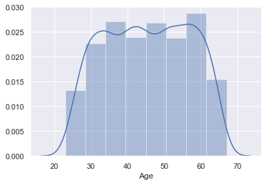

```python
sns.distplot(dataset['Age'], bins=8);
```

The age distribution is largely between 30-60 group. Since the age is in the form of discrete values, we can try grouping them into bins next.

We will divide the age groups into 20-40, 41-60, 61-80 categories.

```python
dataset['Age'] = pd.cut(x=dataset['Age'], bins=[20, 40, 60, 80],
                    labels=['1', '2', '3'])
print(dataset['Age'].unique())
```

```
[1, 2, 3]
Categories (3, object): [1 < 2 < 3]
```

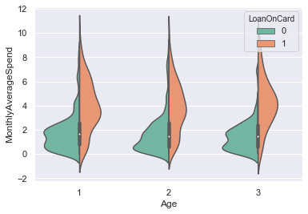

```python
sns.violinplot(dataset['Age'], dataset['MonthlyAverageSpend'], hue=dataset['LoanOnCard'], palette='Set2', split=True) ;
```

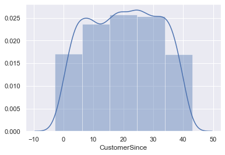

```python
sns.distplot(dataset['CustomerSince'], bins=5);
```

Similarly, we can bin the customerSince column into categories.

```python
dataset['CustomerSince'] = pd.cut(x=dataset['CustomerSince'], bins=[-5, 0, 10, 20,30,40,50],
                    labels=['1', '2', '3', '4','5','6'])
```

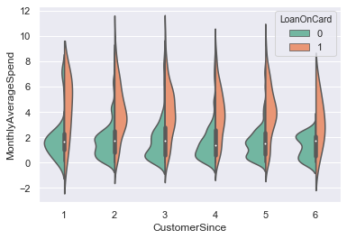

```python
sns.violinplot(dataset['CustomerSince'], dataset['MonthlyAverageSpend'], hue=dataset['LoanOnCard'], palette='Set2', split=True) ;
```

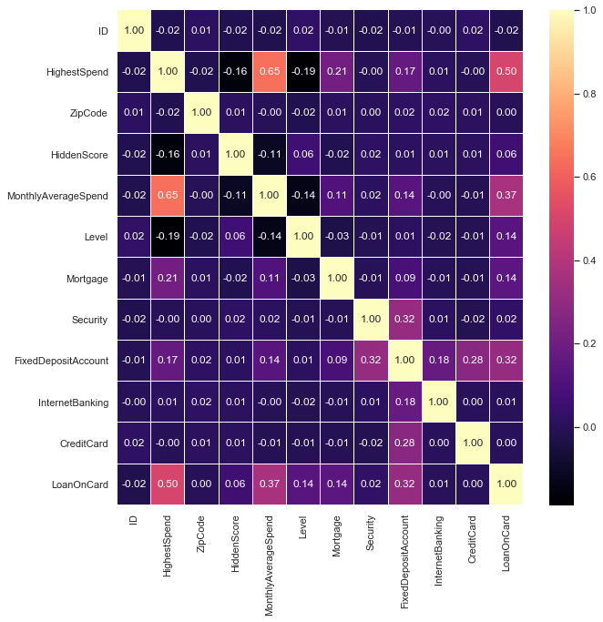

```python
fig,ax = plt.subplots(figsize=(10, 10))
sns.heatmap(dataset.corr(), ax=ax, annot=True, linewidths=0.05, fmt= '.2f',cmap="magma") # the color intensity is based on
plt.show()
```

## 4. Data Pre-processing

As seen earlier, we have a singnificant target imbalance. So, we will downsample the dataset

```python
from sklearn.utils import resample

# Separate majority and minority classes
df_majority = dataset[dataset.LoanOnCard == 0]
df_minority = dataset[dataset.LoanOnCard == 1]

df_dsampled_majority = resample(df_majority,
                                 replace=False,     # sample with replacement
                                 n_samples=480,    # to match majority class
                                 random_state=123) # reproducible results

# Combine majority class with upsampled minority class
df_dsampled = pd.concat([df_minority, df_dsampled_majority])

# Display new class counts
print(f"After down-sampling: \n{df_dsampled.LoanOnCard.value_counts()}")
df_dsampled.head()
```

```
After down-sampling:
1    480
0    480
Name: LoanOnCard, dtype: int64
```

|  | ID | Age | CustomerSince | HighestSpend | ZipCode | HiddenScore | MonthlyAverageSpend | Level | Mortgage | Security | FixedDepositAccount | InternetBanking | CreditCard | LoanOnCard |
| --- | --- | --- | --- | --- | --- | --- | --- | --- | --- | --- | --- | --- | --- | --- |
| 9 | 10 | 1 | 2 | 180 | 93023 | 1 | 8.9 | 3 | 0 | 0 | 0 | 0 | 0 | 1 |
| 16 | 17 | 1 | 3 | 130 | 95010 | 4 | 4.7 | 3 | 134 | 0 | 0 | 0 | 0 | 1 |
| 18 | 19 | 2 | 4 | 193 | 91604 | 2 | 8.1 | 3 | 0 | 0 | 0 | 0 | 0 | 1 |
| 29 | 30 | 1 | 3 | 119 | 94104 | 1 | 3.3 | 2 | 0 | 0 | 1 | 1 | 1 | 1 |
| 38 | 39 | 2 | 3 | 141 | 94114 | 3 | 5.0 | 3 | 0 | 1 | 1 | 1 | 0 | 1 |

- Segregate predictors vs target attributes

```python
# Segregate predictors v/s target variables
X = df_dsampled.drop(['ID', 'LoanOnCard'], axis=1)
y = df_dsampled['LoanOnCard']
```

```python
# split into train and test
X_train, X_test, y_train, y_test = train_test_split(X, y, test_size=0.3, random_state=7)
print(f"Shape of: X_train={X_train.shape} ; X_test={X_test.shape} ; y_train={y_train.shape} ; y_test={y_test.shape}")
```

```
Shape of: X_train=(672, 12) ; X_test=(288, 12) ; y_train=(672,) ; y_test=(288,)
```

### Model: Naive Bayes:

```python
# Train naive bayes classification
from sklearn.naive_bayes import GaussianNB
gnb = GaussianNB()
NBmodel =  gnb.fit(X_train, y_train)
y_pred = NBmodel.predict(X_test)
print("Number of mislabeled points out of a total %d points : %d" % (X_test.shape[0], (y_test != y_pred).sum()))
```

```
Number of mislabeled points out of a total 288 points : 56
```

```
Accuracy Score: 0.8055555555555556
```

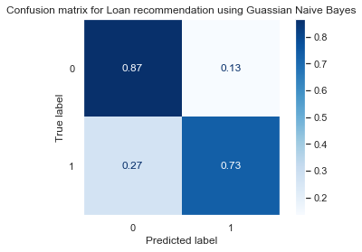

```python
# evaluate accuracy
print(f"{color.BOLD+color.PURPLE}Accuracy Score: {accuracy_score(y_test, y_pred)}")

disp = plot_confusion_matrix(gnb, X_test, y_test, cmap=plt.cm.Blues,
                                 normalize='true');
disp.ax_.set_title("Confusion matrix for Loan recommendation using Guassian Naive Bayes")
plt.grid(False)
```

```python
print(f"{color.BOLD+color.PURPLE}Classification report for loan recommendation model using Guassian Naive Bayes{color.END}")
print(classification_report(y_test, y_pred))
```

```
Classification report for loan recommendation model using Guassian Naive Bayes
              precision    recall  f1-score   support

           0       0.80      0.87      0.83       157
           1       0.82      0.73      0.77       131

    accuracy                           0.81       288
   macro avg       0.81      0.80      0.80       288
weighted avg       0.81      0.81      0.80       288
```

Model : Naive Bayes: Bernaoulli

```python
from sklearn.naive_bayes import BernoulliNB
bnb = BernoulliNB()
BNBmodel =  bnb.fit(X_train, y_train)
y_pred = BNBmodel.predict(X_test)
print("Number of mislabeled points out of a total %d points : %d" % (X_test.shape[0], (y_test != y_pred).sum()))
```

```
Number of mislabeled points out of a total 288 points : 114
```

```
Accuracy Score: 0.6041666666666666
```

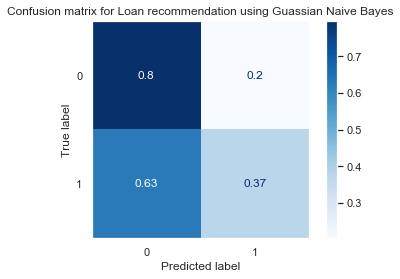

```python
# evaluate accuracy
print(f"{color.BOLD+color.PURPLE}Accuracy Score: {accuracy_score(y_test, y_pred)}")

disp = plot_confusion_matrix(bnb, X_test, y_test, cmap=plt.cm.Blues,
                                 normalize='true');
disp.ax_.set_title("Confusion matrix for Loan recommendation using Guassian Naive Bayes")
plt.grid(False)
```

This model seems to be performing very bad for recommending loans,

```python
params = {'alpha': [0.01, 0.1, 0.5, 1.0, 10.0],
         }

bernoulli_nb_grid = GridSearchCV(BernoulliNB(), param_grid=params, n_jobs=-1, cv=5, verbose=5)
bernoulli_nb_grid.fit(X_train,y_train)
print('Test Accuracy : %.3f'%bernoulli_nb_grid.best_estimator_.score(X_test, y_test))
print('Best Accuracy Through Grid Search : %.3f'%bernoulli_nb_grid.best_score_)
print('Best Parameters : ',bernoulli_nb_grid.best_params_)
```

```
Fitting 5 folds for each of 5 candidates, totalling 25 fits
Test Accuracy : 0.604
Best Accuracy Through Grid Search : 0.609
Best Parameters :  {'alpha': 0.01}
```

**The Bernaulli NB classifier does not give as good accuracy as Gaussian NB classifier**

```python
print(f"{color.BOLD+color.PURPLE}Classification report for loan recommendation model using Guassian Naive Bayes{color.END}")
print(classification_report(y_test, y_pred))
```

```
Classification report for loan recommendation model using Guassian Naive Bayes
              precision    recall  f1-score   support

           0       0.60      0.80      0.69       157
           1       0.60      0.37      0.46       131

    accuracy                           0.60       288
   macro avg       0.60      0.59      0.57       288
weighted avg       0.60      0.60      0.58       288
```

### Model: Logistic Regression

```python
from sklearn.linear_model import LogisticRegression
clf = LogisticRegression(random_state=48,penalty='l1',
                         dual=False, tol=0.0001, C=1.0,
                         fit_intercept=True, intercept_scaling=1,
                         class_weight=None, solver='liblinear',
                         max_iter=100, multi_class='auto',
                         verbose=0, warm_start=False, n_jobs=None,
                         l1_ratio=None)
LRmodel = clf.fit(X_train, y_train)
y_pred_lr = LRmodel.predict(X_test)
```

```
Accuracy Score: 0.8923611111111112
```

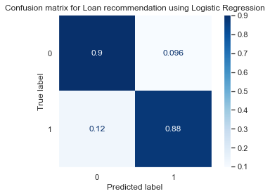

```python
print(f"{color.BOLD+color.PURPLE}Accuracy Score: {accuracy_score(y_test, y_pred_lr)}")

disp = plot_confusion_matrix(clf, X_test, y_test, cmap=plt.cm.Blues,
                                 normalize='true');
disp.ax_.set_title("Confusion matrix for Loan recommendation using Logistic Regression")
plt.grid(False)
```

**Tune the hyper-parameters using GridSearch**

```
Accuracy Score: 0.8958333333333334


The best parameters to tune logistic regression model is:
{'C': 0.09, 'penalty': 'l1', 'random_state': 48, 'solver': 'liblinear'}
```

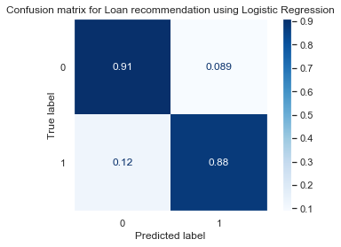

```python
from sklearn.model_selection import GridSearchCV
grid_values = {'penalty': ['l1', 'l2'],'C':[0.001,.009,0.01,.09,1,5], 'solver':['liblinear'], 'random_state':[48]}
grid_clf_acc = GridSearchCV(clf, param_grid = grid_values,scoring = 'recall')
xmodel = grid_clf_acc.fit(X_train, y_train)
y_pred_gs = xmodel.predict(X_test)
# evaluate accuracy
print(f"{color.BOLD+color.PURPLE}Accuracy Score: {accuracy_score(y_test, y_pred_gs)}")

disp = plot_confusion_matrix(grid_clf_acc, X_test, y_test, cmap=plt.cm.Blues,
                                 normalize='true');
disp.ax_.set_title("Confusion matrix for Loan recommendation using Logistic Regression")
print(f"\n\nThe best parameters to tune logistic regression model is: \n{grid_clf_acc.best_params_}")
plt.grid(False)
```

**To check if the model is not overfitted, lets perform a cross-validation test.**

```python
from sklearn.model_selection import cross_val_score
```

```python
scores = cross_val_score(grid_clf_acc, X, y, cv=5, scoring='f1_macro')
print("%0.2f accuracy with a standard deviation of %0.2f" % (scores.mean(), scores.std()))
```

```
0.90 accuracy with a standard deviation of 0.01
```

```python
print(f"{color.BOLD+color.PURPLE}Classification report for loan recommendation model using Logistic regression{color.END}")
print(classification_report(y_test, y_pred_lr))
```

```
Classification report for loan recommendation model using Logistic regression
              precision    recall  f1-score   support

           0       0.90      0.90      0.90       157
           1       0.88      0.88      0.88       131

    accuracy                           0.89       288
   macro avg       0.89      0.89      0.89       288
weighted avg       0.89      0.89      0.89       288
```

The classification report of identifying potential loan candidates using logistic regression has a good result. We have a good f1-score for identification of both cases with a very high support value. Good precision values of 90 and 88 % for LoanOnCreditCard gives a good confidence for pursing on the results for targetting customers.

### Best Model:

The logic regression model with parameters to tune logistic regression model `{'C': 0.09, 'penalty': 'l1', 'random_state': 48, 'solver': 'liblinear'}` seems to be giving a good recommendation. To verify, thatit is not over-fitting, cross-validation was performed on it and it gave a score of nearly 90 percent.

## 6. Conclusion and improvisation

**Conclusion**

A logistic regression model with above given parameters was found to work with a nearly 90 percent accuracy and is expected to give the marketing team a better shot at targetting the right customers for loans.

**Improvisation**